# OrthoWatch — post-market surveillance of orthopedic device reports

FDA MAUDE, 2020–2024 · control-chart trending · PRR/ROR signals · narrative mining

Published

August 22, 2026

## What this is

84,547 cleaned adverse event reports on orthopedic devices, drawn from the FDA’s MAUDE database (2020-01 to 2024-12) and screened three ways: *when* did reporting move (control charts), *what* problems attach to *which* device families (disproportionality statistics), and what the free-text narratives say that the coded fields don’t (text mining).

**Read this first.** MAUDE reports are unverified reporter submissions. Counts reflect reporting behavior as much as device performance; report volume says nothing about how many devices are in use. Every flag and signal below means *investigate* — never *unsafe* — and nothing in this report is a finding about any product.

Cleaned reports per device family.

| Device family | Reports |
| --- | --- |
| Knee prosthesis | 33,834 |
| Hip prosthesis | 30,754 |
| Bone plate | 11,097 |
| Spinal fixation | 8,852 |
| Other | 10 |

## When: monthly trends against control limits

Each family’s monthly report count, with a band at the mean ± 3 standard deviations — the century-old control-chart convention: ordinary randomness lives inside the band; points outside deserve a question.

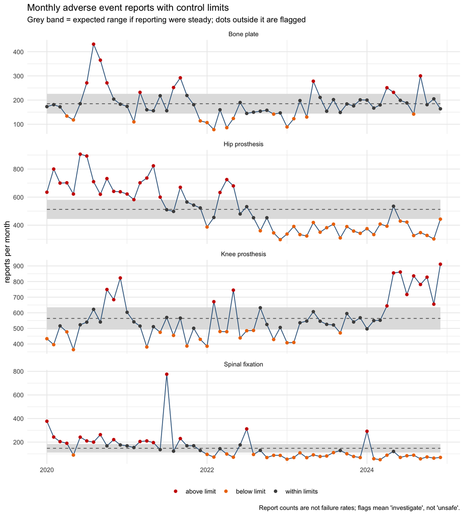

The ten most extreme flagged months.

| Family | Month | Reports | Average | Status | SD from avg |
| --- | --- | --- | --- | --- | --- |
| Spinal fixation | 2021-07 | 776 | 147.5333 | above limit | 51.7 |
| Spinal fixation | 2020-01 | 377 | 147.5333 | above limit | 18.9 |
| Bone plate | 2020-08 | 431 | 184.9500 | above limit | 18.1 |
| Hip prosthesis | 2020-06 | 906 | 512.5667 | above limit | 17.4 |
| Hip prosthesis | 2020-07 | 893 | 512.5667 | above limit | 16.8 |
| Knee prosthesis | 2024-12 | 911 | 563.9000 | above limit | 14.6 |
| Hip prosthesis | 2021-05 | 823 | 512.5667 | above limit | 13.7 |
| Spinal fixation | 2022-07 | 312 | 147.5333 | above limit | 13.5 |
| Bone plate | 2020-09 | 365 | 184.9500 | above limit | 13.2 |
| Hip prosthesis | 2020-02 | 800 | 512.5667 | above limit | 12.7 |

Two caveats the numbers themselves taught: these series **trend** strongly, and a single five-year mean over-flags trending series (152 of 240 months flag — rolling-baseline limits are the documented refinement on the roadmap); and the tallest towers here turned out, on investigation, to reflect **reporting behavior** — batch submissions concentrated in single reporters — rather than devices deteriorating.

## What: disproportionality signals (PRR/ROR)

For every (family, problem) pair, the 2×2-table statistics standard in vigilance, judged by the published Evans rule (PRR ≥ 2, χ² ≥ 4, at least 3 reports). Because each family is its own denominator, these are immune to the volume trends above.

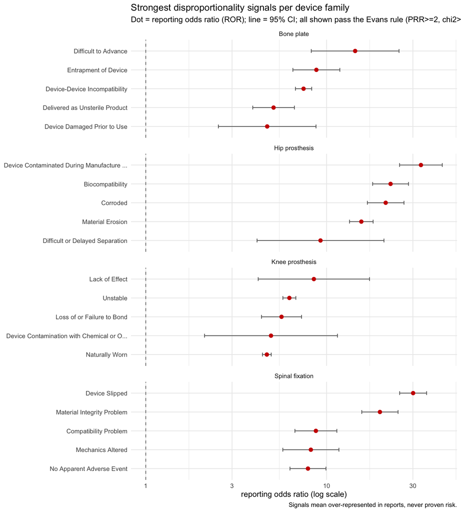

The ten strongest signals by PRR.

| Family | Problem | Reports (a) | PRR | ROR | CI low | CI high |
| --- | --- | --- | --- | --- | --- | --- |
| Hip prosthesis | Device Contaminated During Manufacture or Shipping | 1012 | 32.2 | 33.2 | 25.3 | 43.6 |
| Spinal fixation | Device Slipped | 571 | 28.2 | 30.1 | 25.4 | 35.7 |
| Hip prosthesis | Biocompatibility | 1001 | 21.9 | 22.6 | 18.0 | 28.4 |
| Hip prosthesis | Corroded | 908 | 20.6 | 21.2 | 16.8 | 26.8 |
| Spinal fixation | Material Integrity Problem | 236 | 19.2 | 19.7 | 15.6 | 24.8 |
| Hip prosthesis | Material Erosion | 1624 | 14.8 | 15.6 | 13.4 | 18.1 |
| Bone plate | Difficult to Advance | 39 | 14.3 | 14.4 | 8.2 | 25.2 |
| Hip prosthesis | Difficult or Delayed Separation | 37 | 9.2 | 9.3 | 4.1 | 20.8 |
| Bone plate | Entrapment of Device | 100 | 8.7 | 8.8 | 6.5 | 11.8 |
| Spinal fixation | Compatibility Problem | 109 | 8.6 | 8.7 | 6.7 | 11.4 |

The 64 passing pairs cohere clinically — a metal-degradation cluster for hips, slippage and integrity for spinal fixation, wear and instability for knees, an intraoperative-fit cluster for bone plates — and the method validates itself: the dataset’s largest, vaguest problem category signals for no family, exactly as a category present everywhere should. Over-reported ≠ over-occurring: signals open investigations, never close them.

## What the stories say: narrative vocabulary

The coded fields are the tip of each report; the free-text narrative is the substance. After tokenizing the narratives and stripping filler, each family’s most distinctive words (rate in the family vs. everyone else — the same 2×2 arithmetic, applied to vocabulary):

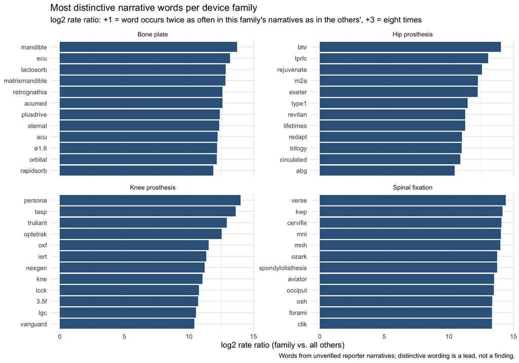

Text mining’s two contributions here: it exposed a **subpopulation the codes hid** (the bone-plate family contains a large craniofacial/mandibular plating subgroup), and it **corroborated the coded signals from an independent direction** (hip narratives orbit a metal-on-metal resurfacing device class by name). It also settled two open questions by reading: the vague-coded reports’ stories often contain specifics the codes omit, and one odd spinal signal traced to a single reporter’s legal-disclaimer template — a reporting pattern, not a device pattern.

## How this report was made

This is an executable document: rendering it re-runs every query and figure against `data/processed/orthowatch.db`, which is itself rebuilt by a one-command pipeline (`Rscript run_pipeline.R`) whose final stage is the project’s 50-test suite. Same raw files in, same report out. Source, tutorials, and the full build story: github.com/akannan2987/orthowatch.